# Portuguese Bank Marketing Data - Raju Hegde

Project Background : The data is related with direct marketing campaigns of a Portuguese banking institution. The marketing campaigns were based on phone calls. Often, more than one contact to the same client was required, in order to access if the product (bank term deposit) would be ('yes') or not ('no') subscribed.

Nowadays, banks are spending lot of money and time on marketing campaign and its very essential for the banking industry. Understanding the customer needes will help any industry to make solid marketing plans, effective products and ultimately this leads to customer satisfaction.

Main objective is to improve the effectiveness of telemarketing campaign

This project will help banking institute to understand the customer in detail,predict customer response to telemarketing campaign and establish target customer profile for future marketing.

Attribute Information:

1. age (numeric)
2. job : type of job (categorical: 'admin.','blue-collar','entrepreneur','housemaid','manage ment','retired','self-employed','services','student','technicia n','unemployed','unknown')
3. marital : marital status (categorical: 'divorced','married','single','unknown'; note: 'divorced' means divorced or widowed)
4. education (categorical: 'basic.4y','basic.6y','basic.9y','high.school','illiterate','profes sional.course','university.degree','unknown')
5. default: has credit in default? (categorical: 'no','yes','unknown')
6. balance: average yearly balance, in euros (numeric)
7. housing: has housing loan? (categorical: 'no','yes','unknown')
8. loan: has personal loan? (categorical: 'no','yes','unknown')
9. contact: contact communication type (categorical: 'cellular','telephone')
10. day: last contact day of the month (numeric 1 -31)
11. month: last contact month of year (categorical: 'jan', 'feb', 'mar', ..., 'nov', 'dec')
12. duration: last contact duration, in seconds (numeric). Important note: this attribute highly affects the output target (e.g., if duration=0 then y='no'). Yet, the duration is not known before a call is performed. Also, after the end of the call y is obviously known. Thus, this input should only be included for benchmark purposes and should be discarded if the intention is to have a realistic predictive model.
13. campaign: number of contacts performed during this campaign and for this client (numeric, includes last contact)
14. pdays: number of days that passed by after the client was last contacted from a previous campaign (numeric; 999 means client was not previously contacted)
15. previous: number of contacts performed before this campaign and for this client (numeric)
16. poutcome: outcome of the previous marketing campaign (categorical: 'failure','nonexistent','success')
17. target: has the client subscribed a term deposit? (binary: "yes","no")

```python
# Import all neccessary Library
import pandas as pd
import numpy as np
from sklearn import metrics
import matplotlib.pyplot as plt
%matplotlib inline
import seaborn as sns
from sklearn.model_selection import train_test_split
from sklearn.tree import DecisionTreeClassifier
#from sklearn.feature_extraction.text import CountVectorizer  #DT does not take strings as input for the model fit step....
from IPython.display import Image
#import pydotplus as pydot
from sklearn import tree
from os import system
import warnings
warnings.filterwarnings('ignore')
import os
```

```python
dataset = pd.read_csv('/users/rajuhegde/desktop/Greatlearning/GLProjects/Bank telemarketing/bank-full.csv')
```

```python
dataset.head()
```

|  | age | job | marital | education | default | balance | housing | loan | contact | day | month | duration | campaign | pdays | previous | poutcome | Target |
| --- | --- | --- | --- | --- | --- | --- | --- | --- | --- | --- | --- | --- | --- | --- | --- | --- | --- |
| 0 | 58 | management | married | tertiary | no | 2143 | yes | no | unknown | 5 | may | 261 | 1 | -1 | 0 | unknown | no |
| 1 | 44 | technician | single | secondary | no | 29 | yes | no | unknown | 5 | may | 151 | 1 | -1 | 0 | unknown | no |
| 2 | 33 | entrepreneur | married | secondary | no | 2 | yes | yes | unknown | 5 | may | 76 | 1 | -1 | 0 | unknown | no |
| 3 | 47 | blue-collar | married | unknown | no | 1506 | yes | no | unknown | 5 | may | 92 | 1 | -1 | 0 | unknown | no |
| 4 | 33 | unknown | single | unknown | no | 1 | no | no | unknown | 5 | may | 198 | 1 | -1 | 0 | unknown | no |

```python
dataset.info()
```

```
<class 'pandas.core.frame.DataFrame'>
RangeIndex: 45211 entries, 0 to 45210
Data columns (total 17 columns):
age          45211 non-null int64
job          45211 non-null object
marital      45211 non-null object
education    45211 non-null object
default      45211 non-null object
balance      45211 non-null int64
housing      45211 non-null object
loan         45211 non-null object
contact      45211 non-null object
day          45211 non-null int64
month        45211 non-null object
duration     45211 non-null int64
campaign     45211 non-null int64
pdays        45211 non-null int64
previous     45211 non-null int64
poutcome     45211 non-null object
Target       45211 non-null object
dtypes: int64(7), object(10)
memory usage: 5.9+ MB
```

there are 45211 observations in this dataset. each represents the customer reach via phone call.

1. For each observations, the dataset records 16input variables and that stand for both qualitative and qualtitative attributes of the customer, such as age,job,housing and personal loan status,account balance and the number of contacts.
2. There is a single binary output variable that denotes 'yes' or 'no' revealing the outcomes of the phone calls.

Cleaning the dataset:

```python
# Step 1 : Delete the rows in which column 'poutcome' contains 'other'
condition = dataset.poutcome=='other'
data = dataset.drop(dataset[condition].index,axis=0,inplace=False)
```

```python
data.head()
```

|  | age | job | marital | education | default | balance | housing | loan | contact | day | month | duration | campaign | pdays | previous | poutcome | Target |
| --- | --- | --- | --- | --- | --- | --- | --- | --- | --- | --- | --- | --- | --- | --- | --- | --- | --- |
| 0 | 58 | management | married | tertiary | no | 2143 | yes | no | unknown | 5 | may | 261 | 1 | -1 | 0 | unknown | no |
| 1 | 44 | technician | single | secondary | no | 29 | yes | no | unknown | 5 | may | 151 | 1 | -1 | 0 | unknown | no |
| 2 | 33 | entrepreneur | married | secondary | no | 2 | yes | yes | unknown | 5 | may | 76 | 1 | -1 | 0 | unknown | no |
| 3 | 47 | blue-collar | married | unknown | no | 1506 | yes | no | unknown | 5 | may | 92 | 1 | -1 | 0 | unknown | no |
| 4 | 33 | unknown | single | unknown | no | 1 | no | no | unknown | 5 | may | 198 | 1 | -1 | 0 | unknown | no |

```python
#step 2 : Fill 'unknown' in job and education to 'other'

data[['job','education']] = data[['job','education']].replace(['unknown'],'other')
```

```python
data.describe().transpose()
```

|  | count | mean | std | min | 25% | 50% | 75% | max |
| --- | --- | --- | --- | --- | --- | --- | --- | --- |
| age | 43371.0 | 40.986443 | 10.595454 | 18.0 | 33.0 | 39.0 | 48.0 | 95.0 |
| balance | 43371.0 | 1356.963063 | 3030.956348 | -8019.0 | 70.0 | 443.0 | 1417.0 | 102127.0 |
| day | 43371.0 | 15.862904 | 8.324122 | 1.0 | 8.0 | 16.0 | 21.0 | 31.0 |
| duration | 43371.0 | 258.266930 | 257.950498 | 0.0 | 103.0 | 180.0 | 318.0 | 4918.0 |
| campaign | 43371.0 | 2.776671 | 3.138053 | 1.0 | 1.0 | 2.0 | 3.0 | 63.0 |
| pdays | 43371.0 | 32.158954 | 90.689195 | -1.0 | -1.0 | -1.0 | -1.0 | 871.0 |
| previous | 43371.0 | 0.434853 | 1.559405 | 0.0 | 0.0 | 0.0 | 0.0 | 55.0 |

Drop outliers in the balance column : In order to capture general trend the dataset.outliers are defined as the values which are more than three standard deviations away from the mean

```python
from scipy.stats import zscore

dataset[['balance']].mean()
dataset['balance_outliers']=dataset[['balance']]
dataset['balance_outliers'] = zscore(dataset['balance_outliers'])

condition1=(dataset['balance_outliers']>3)|(dataset['balance_outliers']<-3)

df1 = dataset.drop(dataset[condition1].index,axis=0,inplace=False)
```

```python
dataframe1 = df1.drop('balance_outliers',axis=1)
```

Creating & Transforming data

```python
def convert(dataframe1,new_column,old_column):
    dataframe1[new_column]=dataframe1[old_column].apply(lambda x: 0 if x=='no' else 1)
    return dataframe1[new_column].value_counts()
convert(dataframe1,'Target_binary','Target')
```

```
0    39298
1     5168
Name: Target_binary, dtype: int64
```

```python
# step 1 : Drop column 'contact' which will not contribute
dataframe2 = dataframe1.drop('contact',axis=1)
```

```python
#step 2 : change the unit of 'duration' from seconds to minute
dataframe2['duration'] = dataframe2['duration'].apply(lambda n:n/60).round(2)
```

```python
#step3 : Change the 'month' from words to numbers for easier analysis
X = [dataframe2]
for column in X:
    column.loc[column['month']=='jan','month_int']=1
    column.loc[column['month']=='feb','month_int']=2
    column.loc[column['month']=='mar','month_int']=3
    column.loc[column['month']=='apr','month_int']=4
    column.loc[column['month']=='may','month_int']=5
    column.loc[column['month']=='jun','month_int']=6
    column.loc[column['month']=='jul','month_int']=7
    column.loc[column['month']=='aug','month_int']=8
    column.loc[column['month']=='sept','month_int']=9
    column.loc[column['month']=='oct','month_int']=10
    column.loc[column['month']=='nov','month_int']=11
    column.loc[column['month']=='dec','month_int']=12
```

Filtering

```python
# step1 : drop rows that 'duration' < 5s
condition2 = (dataframe2['duration']<5/60)
dataframe3 = dataframe2.drop(dataframe2[condition2].index,axis=0,inplace=False)
```

```python
#Step2 : drop customer values with 'other' education
condition3=(dataframe3['education']=='other')
dataframe4=dataframe3.drop(dataframe3[condition3].index,axis=0,inplace=False)
```

```python
dataframe4.head()
```

|  | age | job | marital | education | default | balance | housing | loan | day | month | duration | campaign | pdays | previous | poutcome | Target | Target_binary | month_int |
| --- | --- | --- | --- | --- | --- | --- | --- | --- | --- | --- | --- | --- | --- | --- | --- | --- | --- | --- |
| 0 | 58 | management | married | tertiary | no | 2143 | yes | no | 5 | may | 4.35 | 1 | -1 | 0 | unknown | no | 0 | 5.0 |
| 1 | 44 | technician | single | secondary | no | 29 | yes | no | 5 | may | 2.52 | 1 | -1 | 0 | unknown | no | 0 | 5.0 |
| 2 | 33 | entrepreneur | married | secondary | no | 2 | yes | yes | 5 | may | 1.27 | 1 | -1 | 0 | unknown | no | 0 | 5.0 |
| 3 | 47 | blue-collar | married | unknown | no | 1506 | yes | no | 5 | may | 1.53 | 1 | -1 | 0 | unknown | no | 0 | 5.0 |
| 4 | 33 | unknown | single | unknown | no | 1 | no | no | 5 | may | 3.30 | 1 | -1 | 0 | unknown | no | 0 | 5.0 |

```python
dataframe4.shape
```

```
(44406, 18)
```

```python
dataframe4.info()
```

```
<class 'pandas.core.frame.DataFrame'>
Int64Index: 44406 entries, 0 to 45210
Data columns (total 18 columns):
age              44406 non-null int64
job              44406 non-null object
marital          44406 non-null object
education        44406 non-null object
default          44406 non-null object
balance          44406 non-null int64
housing          44406 non-null object
loan             44406 non-null object
day              44406 non-null int64
month            44406 non-null object
duration         44406 non-null float64
campaign         44406 non-null int64
pdays            44406 non-null int64
previous         44406 non-null int64
poutcome         44406 non-null object
Target           44406 non-null object
Target_binary    44406 non-null int64
month_int        43847 non-null float64
dtypes: float64(2), int64(7), object(9)
memory usage: 6.4+ MB
```

```python
dataframe4.describe().transpose()
```

|  | count | mean | std | min | 25% | 50% | 75% | max |
| --- | --- | --- | --- | --- | --- | --- | --- | --- |
| age | 44406.0 | 40.890353 | 10.595450 | 18.0 | 33.00 | 39.0 | 48.00 | 95.00 |
| balance | 44406.0 | 1084.888236 | 1721.236458 | -6847.0 | 68.00 | 431.0 | 1348.00 | 10483.00 |
| day | 44406.0 | 15.802459 | 8.327571 | 1.0 | 8.00 | 16.0 | 21.00 | 31.00 |
| duration | 44406.0 | 4.306691 | 4.290736 | 0.1 | 1.72 | 3.0 | 5.32 | 81.97 |
| campaign | 44406.0 | 2.765640 | 3.098554 | 1.0 | 1.00 | 2.0 | 3.00 | 63.00 |
| pdays | 44406.0 | 40.170112 | 99.935874 | -1.0 | -1.00 | -1.0 | -1.00 | 871.00 |
| previous | 44406.0 | 0.579201 | 2.310299 | 0.0 | 0.00 | 0.0 | 0.00 | 275.00 |
| Target_binary | 44406.0 | 0.116381 | 0.320684 | 0.0 | 0.00 | 0.0 | 0.00 | 1.00 |
| month_int | 43847.0 | 6.089858 | 2.390054 | 1.0 | 5.00 | 6.0 | 7.00 | 12.00 |

# Exploratory Data analysis :

A. Visualize the distribution of 'age' and 'balance'

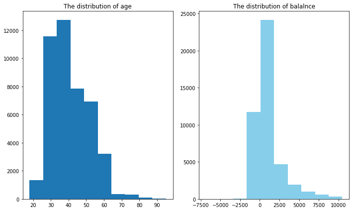

```python
dist_age_balance = plt.figure(figsize=(10,6))

ra1 = dist_age_balance.add_subplot(1,2,1)
ra2 = dist_age_balance.add_subplot(1,2,2)

ra1.hist(dataframe4['age'])
ra1.set_title('The distribution of age')

ra2.hist(dataframe4['balance'],color='skyblue')
ra2.set_title('The distribution of balalnce')
plt.tight_layout()
plt.show()
```

B. Relationship between age & balance

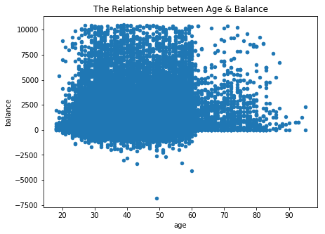

```python
scatter_age_balance = dataframe4.plot.scatter('age','balance',figsize=(7,5))
plt.title('The Relationship between Age & Balance')
plt.show()
```

Based on this scatter plot, we are not finding any clear relationship between clients age and balance level. but, over the age og 60, clients tend to have a significantly lower balalnce mostly under 5000 euros. this may be the reason like people will retire after 60yrs, so no longer have reliable income sources.

C. Visualize the distribution of 'duration' & 'campaign'

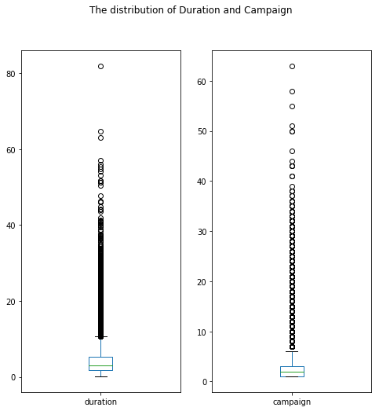

```python
dist_dur_cam = dataframe4[['duration','campaign']].plot(kind='box',
figsize=(8,8),subplots = True,layout=(1,2),sharex =False, sharey = False,title = 'The distribution of Duration and Campaign')
plt.show()
```

D. Visualize the relationship between 'duration' and 'campaign' with 'target' result

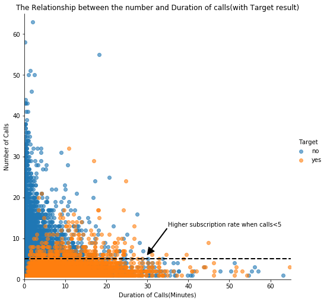

```python
dur_cam = sns.lmplot(x='duration',y='campaign',data = dataframe4,hue='Target',fit_reg=False,scatter_kws={'alpha':0.6},height=7)
plt.axis([0,65,0,65])
plt.ylabel('Number of Calls')
plt.xlabel('Duration of Calls(Minutes)')
plt.title('The Relationship between the number and Duration of calls(with Target result)')
#annotation
plt.axhline(y=5,linewidth=2,color='k', linestyle = '--')
plt.annotate('Higher subscription rate when calls<5',xytext=(35,13),arrowprops=dict(color='k',width=1),xy=(30,6))
plt.show()
```

Observation : In this plot, clients who subcribed to term deposit are denoted as 'yes' while those didnt are denoted as 'no'.

As we can see from the plot, 'yes' clients and 'no'clients are forming two relatively seperate clusters. Compared to 'no' clients, 'yes 'clients are contacted fewr times and had longer call duration. more importantly, after 5,6 or 7 campaign calls, clients are more likely to reject the term deposit unless the dduration is high. most 'yes' clients were approached less than 10times.

So this suggests the bank should resists calling a client for more than five times, which can be disturbing and increase dissatisfaction.

E. Scatter Matrix & Correlation Matrix

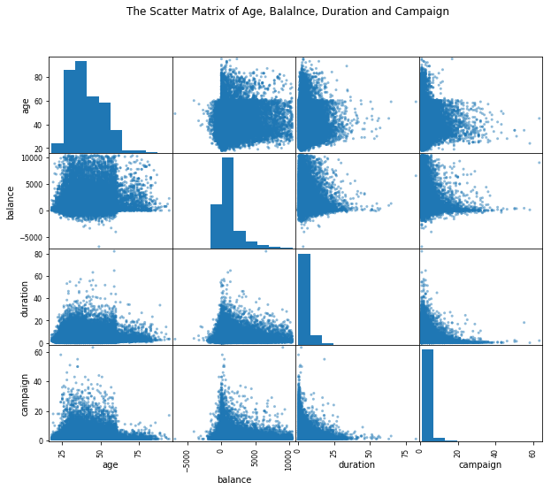

```python
from pandas.plotting import scatter_matrix
matrix = scatter_matrix(dataframe4[['age','balance','duration','campaign']],figsize=(10,8))
plt.suptitle('The Scatter Matrix of Age, Balalnce, Duration and Campaign')
plt.show()
```

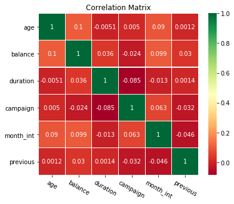

```python
corr_data=dataframe4[['age','balance','duration','campaign','month_int','previous','Target']]
corr=corr_data.corr()
cor_plot = sns.heatmap(corr,annot=True,cmap="RdYlGn",linewidths=0.2,annot_kws={'size':10})
fig=plt.gcf()
fig.set_size_inches(6,5)
plt.xticks(fontsize=10,rotation=-30)
plt.yticks(fontsize=10)
plt.title('Correlation Matrix')
plt.show()
```

Observation : The scatter matrx does not reveal any clear relationship among age,balance,duration and campaign.

[output not shown]

# Data Visulization

```python
xyz = [dataframe4]
for column in xyz:
    column.loc[column['age']<30,'age_group'] = 20
    column.loc[(column['age']>=30) & (column['age']<=39),'age_group']=30
    column.loc[(column['age']>=40) & (column['age']<=49),'age_group']=40
    column.loc[(column['age']>=50) & (column['age']<=59),'age_group']=50
    column.loc[(column['age']>=60) & (column['age']<=69),'age_group']=60
```

```python
count_age_Target_pct=pd.crosstab(dataframe4['Target'],dataframe4['age_group']).apply(lambda x: x/x.sum()*100)
count_age_Target_pct = count_age_Target_pct.transpose()
```

```python
age=pd.DataFrame(dataframe4['age_group'].value_counts())
age['% Contacted'] = age['age_group']*100/age['age_group'].sum()
age['% Subscription']=count_age_Target_pct['yes']
age.drop('age_group',axis=1,inplace=True)
age['age']=[30,40,50,20,60]
age=age.sort_values('age',ascending = True)
```

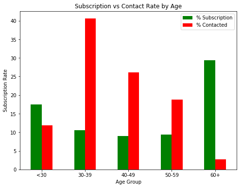

```python
plot_age=age[['% Subscription','% Contacted']].plot(kind='bar',figsize=(8,6),color=('green','red'))
plt.xlabel('Age Group')
plt.ylabel('Subscription Rate')
plt.xticks(np.arange(5),('<30','30-39','40-49','50-59','60+'),rotation='horizontal')
plt.title('Subscription vs Contact Rate by Age')
plt.show()
```

1. Its not surprising to see such a pattern because the main investment objective of older people is saving for retirement while the midle-aged group tend to be more aggressive with a main objective of generating high investment income. Term deposits, as teh least risky investment tool, are more preferable to the eldest.
2. The youngest may not have enough money or professional knowledge to enagage in sophisticated investments,such as stocks and mutual funds. Term deposits provide liquidity and generate interest incomes that are higher than the regular saving accounts, so term deposits are ideal investment for students.

However, red vertical bars show the bank focused its marketing efforts on the midle aged people, which returned lower subscription rates than the younger and older groups.To make campaign more effective bank should target young and old people in future.

B. Subscription rate by balance level

```python
lst = [dataframe4]
for column in lst:
    column.loc[column["balance"] <= 0,  'balance_group'] = 'no balance'
    column.loc[(column["balance"] > 0) & (column["balance"] <= 1000), 'balance_group'] = 'low balance'
    column.loc[(column["balance"] > 1000) & (column["balance"] <= 5000), 'balance_group'] = 'average balance'
    column.loc[(column["balance"] > 5000), 'balance_group'] = 'high balance'
```

```python
count_balance_response_pct=pd.crosstab(dataframe4['Target'],dataframe4['balance_group']).apply(lambda x: x/x.sum()*100)
count_balance_response_pct=count_balance_response_pct.transpose()
```

```python
bal=pd.DataFrame(dataframe4['balance_group'].value_counts())
bal['% Contacted'] = bal['balance_group']*100/bal['balance_group'].sum()
bal['% Subscription'] = count_balance_response_pct['yes']
bal.drop('balance_group',axis =1,inplace=True)


bal['bal'] = [1,2,0,3]
bal=bal.sort_values('bal',ascending = True)
```

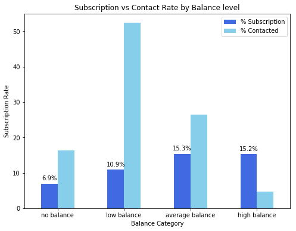

```python
plot_balance=bal[['% Subscription','% Contacted']].plot(kind='bar',color=('royalblue','skyblue'),figsize=(8,6))


plt.ylabel('Subscription Rate')
plt.xticks(rotation='horizontal')
plt.title('Subscription vs Contact Rate by Balance level')
plt.xlabel('Balance Category')

#label the bar
for rec,label in zip(plot_balance.patches,bal['% Subscription'].round(1).astype(str)):
    plot_balance.text(rec.get_x()+rec.get_width()/2,rec.get_height()+1,label+'%',ha='center',color='black')

plt.show()
```

Insights : Target clients have average or high balance

```
Clients are devided into 4 categories
1. No balance : clients with a negative balance
2. Low balance : Balance 0 to 1000 Euros
3. Average balance : Balance between 1000 to 5000 Euros
4. High balance : clients balance greater than 5000 euros
```

In this campaign more than 50% clients contacted only have a low balance level. In future, the bank should shift its marketing focus to high -balalnce customers to secure more term deposits

C. Subscription Rate by Job

```python
count_job_response_pct = pd.crosstab(dataframe4['Target'],dataframe4['job']).apply(lambda x: x/x.sum() * 100)
count_job_response_pct = count_job_response_pct.transpose()
```

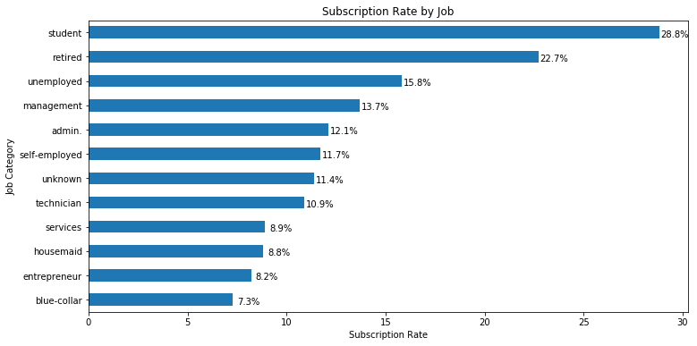

```python
plot_job = count_job_response_pct['yes'].sort_values(ascending = True).plot(kind ='barh',
                                                                           figsize = (12,6))

plt.title('Subscription Rate by Job')
plt.xlabel('Subscription Rate')
plt.ylabel('Job Category')

# Label each bar
for rec, label in zip(plot_job.patches,
                      count_job_response_pct['yes'].sort_values(ascending = True).round(1).astype(str)):
    plot_job.text(rec.get_width()+0.8,
                  rec.get_y()+ rec.get_height()-0.5,
                  label+'%',
                  ha = 'center',
                  va='bottom')
```

Insights: target students and retired clients

# Standard Classification Algorithms

1. Lets drop few coulmns which are not required for modeling.
1. Transform categorical variables into dummy variables since algorithms will take only numerical vriables.

```python
# load the cleaned dataset
dataframe5 = pd.read_csv('/users/rajuhegde/desktop/Greatlearning/GLProjects/Bank telemarketing/bank_cleaned.csv')
```

```python
for col in dataframe5.columns:
    print(col)
```

```
Unnamed: 0
age
job
marital
education
default
balance
housing
loan
day
month
duration
campaign
pdays
previous
poutcome
response
response_binary
```

```python
dataframe5=dataframe5.drop(['Unnamed: 0'],axis=1)
dataframe5.drop(['marital'],axis=1,inplace=True)
```

```python
dataframe5.head()
```

|  | age | job | education | default | balance | housing | loan | day | month | duration | campaign | pdays | previous | poutcome | response | response_binary |
| --- | --- | --- | --- | --- | --- | --- | --- | --- | --- | --- | --- | --- | --- | --- | --- | --- |
| 0 | 58 | management | tertiary | no | 2143 | yes | no | 5 | may | 4.35 | 1 | -1 | 0 | unknown | no | 0 |
| 1 | 44 | technician | secondary | no | 29 | yes | no | 5 | may | 2.52 | 1 | -1 | 0 | unknown | no | 0 |
| 2 | 33 | entrepreneur | secondary | no | 2 | yes | yes | 5 | may | 1.27 | 1 | -1 | 0 | unknown | no | 0 |
| 3 | 35 | management | tertiary | no | 231 | yes | no | 5 | may | 2.32 | 1 | -1 | 0 | unknown | no | 0 |
| 4 | 28 | management | tertiary | no | 447 | yes | yes | 5 | may | 3.62 | 1 | -1 | 0 | unknown | no | 0 |

```python
data_set1=dataframe5.iloc[:,0:7]
```

```python
data_set2=pd.get_dummies(data_set1,columns=['job'])
data_set2=pd.get_dummies(data_set2,columns=['education'])
data_set2['housing']=data_set2['housing'].map({'yes':1,'no':0})
data_set2['default']=data_set2['default'].map({'yes':1,'no':0})
data_set2['loan']=data_set2['loan'].map({'yes':1,'no':0})
dataset_response = pd.DataFrame(dataframe5['response_binary'])
data_set2 = pd.merge(data_set2,dataset_response,left_index=True,right_index = True)
```

1. Feature selection

```python
array = data_set2.values

X=array[:,0:-1]
y=array[:,-1]
```

1. Train/test split

```python
test_size=0.20
seed =0
X_train,X_test,y_train,y_test = train_test_split(X,y,test_size=test_size,random_state=seed)
```

# Compare classification algorithms

Four different classification algorithms(Logistic,KN,Decision Tree & Gaussian NB) are run on dataset and the best performing one will be used to build the classification model.

```python
from sklearn.linear_model import LogisticRegression
from sklearn.neighbors import KNeighborsClassifier
from sklearn.tree import DecisionTreeClassifier
from sklearn.naive_bayes import GaussianNB
from sklearn.model_selection import KFold
from sklearn.model_selection import cross_val_score
```

```python
models = []
models.append(('LR',LogisticRegression()))
models.append(('KNN',KNeighborsClassifier()))
models.append(('CART',DecisionTreeClassifier()))
models.append(('NB',GaussianNB()))
```

```python
results_c = []
names_c=[]
for name,model in models:
    # define how to split off validation data(kfold, how many folds)
    kfold = KFold(n_splits=4,random_state = seed)

    # Train the model

    cv_results=cross_val_score(model,X_train,y_train,cv=kfold,scoring='accuracy')
    results_c.append(cv_results)
    names_c.append(name)
    msg='%s:%f(%f)'%(name,cv_results.mean(),cv_results.std())
    print(msg)
```

```
LR:0.886447(0.001852)
KNN:0.874969(0.002783)
CART:0.830069(0.003618)
NB:0.821590(0.001442)
```

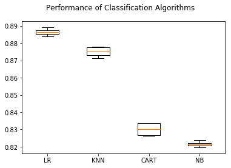

```python
fig=plt.figure()
fig.suptitle("Performance of Classification Algorithms")
ax=fig.add_subplot(111)
plt.boxplot(results_c)
ax.set_xticklabels(names_c)
plt.show()
```

Result : Logistics Regression is the best permorming model

Test LR model on test set

```python
LR =LogisticRegression()
LR.fit(X_train,y_train)
```

```
LogisticRegression(C=1.0, class_weight=None, dual=False, fit_intercept=True,
          intercept_scaling=1, max_iter=100, multi_class='warn',
          n_jobs=None, penalty='l2', random_state=None, solver='warn',
          tol=0.0001, verbose=0, warm_start=False)
```

```python
## Evaluate the model
predictions = LR.predict(X_test)
```

```python
#Accuracy score
from sklearn.metrics import accuracy_score
print(accuracy_score(y_test,predictions))
```

```
0.8861549761292692
```

```
[[7239    0]
 [ 930    0]]
```

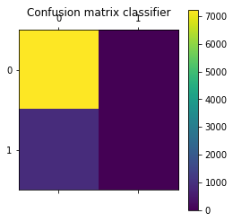

```python
#Confusion Matrix
from sklearn.metrics import confusion_matrix
import pylab as pl
print(confusion_matrix(y_test,predictions))
cm=confusion_matrix(y_test,predictions)
plt.matshow(cm)
pl.title('Confusion matrix classifier')
pl.colorbar()
pl.show()
```

A problwm revealed by this confusion matrix si that the dataset is highly unbalanced, with nearly all client actually decline to subscribe. lets do further evaluation

However, the result of accuracy score can possibly yield misleading result if the data set is unbalanced, because the number of observations in different classes largely vary.

A problem revealed by this confusion matrix is that the dataset is highly unbalanced, with nearly all client actually decline to subscribe. This infers that the accuracy score is biased, and further evaluation should be carried out to determine the accuracy of logistic regression model.

```python
# Classification report
from sklearn.metrics import classification_report
print(classification_report(y_test, predictions))
```

```
              precision    recall  f1-score   support

           0       0.89      1.00      0.94      7239
           1       0.00      0.00      0.00       930

   micro avg       0.89      0.89      0.89      8169
   macro avg       0.44      0.50      0.47      8169
weighted avg       0.79      0.89      0.83      8169
```